# Competing Risks2026 Practicals III

Author

Ronald Geskus

Published

### Data

- We again load the packages and the data

```r
library(mstate)
library(ggsurvfit)
library(survminer)
data(ebmt1)
ebmt1 <- within(ebmt1,{
  time <- pmin(srv,rel)/365.25
  stat <-  ifelse(rel<srv,relstat,srvstat*2) #relapse=1, death=2
  type <- factor(stat,
               labels=c("Event-free","Relapse","Death"))
})
```

### 8. Estimation of cause-specific cumulative incidence (PL-form)

- Create the data set with censoring weights for the individuals who experienced the competing event, using either the `finegray` function in the `survival` package or the `crprep` function in the `mstate` package. Do this for both relapse and death as primary event. Include the variables `age`, `score` and `type`. Inspect the first ten rows of this data set with relapse as primary event.

In the `crprep` function, we can use either the `stat` or the `type` column to define the competing risks, and the data set with weights can be created in a single call. In the `finegray` function we need a separate call to the function for each competing risk. Also, only the `type` column is allowed; the variable needs to be a `factor`.

```r
Webmt <- crprep(Tstop="time", status="stat", data=ebmt1, trans=1,
                cens=0, id="patid", keep=c("score","age","type"))
head(Webmt,10)
```

```
   patid    Tstart     Tstop status weight.cens       score age       type count failcode
1      1 0.0000000 4.4079398      0   1.0000000 Medium risk  28 Event-free     1        1
2      2 0.0000000 0.4517454      1   1.0000000 Medium risk  33    Relapse     1        1
3      3 0.0000000 4.1286790      0   1.0000000 Medium risk  38 Event-free     1        1
4      4 0.0000000 3.7672827      0   1.0000000 Medium risk  15 Event-free     1        1
5      5 0.0000000 0.3641342      1   1.0000000 Medium risk  26    Relapse     1        1
6      6 0.0000000 0.1724846      1   1.0000000 Medium risk  22    Relapse     1        1
7      7 0.0000000 2.3490760      0   1.0000000    Low risk   7 Event-free     1        1
8      8 0.0000000 0.1889117      2   1.0000000 Medium risk  44      Death     1        1
9      8 0.1889117 0.1943874      2   1.0000000 Medium risk  44      Death     2        1
10     8 0.1943874 0.2080767      2   0.9994019 Medium risk  44      Death     3        1
```

```r
nrow(subset(Webmt))
```

```
[1] 94284
```

Apart from the `Tstart`, `Tstop` and `status` variables, a column `weight.cens` with the censoring weights has been created. If there had been left truncated data (specified via the `Tstart` argument in `crprep`), another column `weight.trunc` with the truncation weights would have been created. Two further columns have been added, `count` and `failcode`. `failcode` is used to separate the weighted data sets for the two types of end points. `count` gives the row number in the sequence of rows from the same individual. Its usefulness will become apparent in the exercises that follow.

```r
Webmt.Relapse <- finegray(Surv(time,type)~., data=ebmt1, etype="Relapse")
head(Webmt.Relapse, 10)
```

```
   patid  srv srvstat  rel relstat      yrel age       score stat   fgstart    fgstop fgstatus
1      1 1610       0 1610       0      <NA>  28 Medium risk    0 0.0000000 4.4079398        0
2      2  961       1  165       1 1997-1999  33 Medium risk    1 0.0000000 0.4517454        1
3      3 1508       0 1508       0      <NA>  38 Medium risk    0 0.0000000 4.1286790        0
4      4 1376       0 1376       0      <NA>  15 Medium risk    0 0.0000000 3.7672827        0
5      5 1585       0  133       1 1997-1999  26 Medium risk    1 0.0000000 0.3641342        1
6      6  190       1   63       1 1997-1999  22 Medium risk    1 0.0000000 0.1724846        1
7      7  858       0  858       0      <NA>   7    Low risk    0 0.0000000 2.3490760        0
8      8   69       1   69       0      <NA>  44 Medium risk    2 0.0000000 0.1943874        0
9      8   69       1   69       0      <NA>  44 Medium risk    2 0.1943874 0.2108145        0
10     8   69       1   69       0      <NA>  44 Medium risk    2 0.2108145 0.2162902        0
        fgwt
1  1.0000000
2  1.0000000
3  1.0000000
4  1.0000000
5  1.0000000
6  1.0000000
7  1.0000000
8  1.0000000
9  0.9994019
10 0.9987940
```

```r
nrow(Webmt.Relapse)
```

```
[1] 93844
```

The number of rows is slightly different from the number when `crprep` is used. However, it does not affect the estimates. The `finegray` function does not allow for left truncation weights.

- Compute the PL-form of the estimator of the relapse-specific cumulative incidence. Compare the estimates and confidence intervals with the Aalen-Johansen estimator visually.

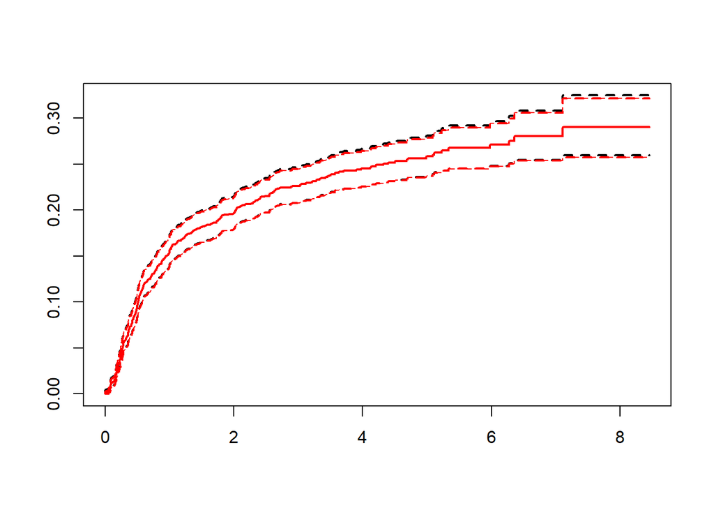

```r
cuminc <- survfit(Surv(time,type)~1, ebmt1) # AJ estimate
cuminc.crprep.rel <- survfit(Surv(Tstart,Tstop,status==1)~1, data=Webmt,
                             weight=weight.cens)
cuminc.finegray.rel <- survfit(Surv(fgstart,fgstop,fgstatus)~1, data=Webmt.Relapse,
                               weight=fgwt)
plot(cuminc[2],lwd=2)
lines(cuminc.crprep.rel, lwd=2, col="red", fun="event")
lines(cuminc.finegray.rel, col="red", fun="event")
```

By looking at the numerical values, we can see that the estimates are the same. The 95% confidence intervals are slightly different. They are computed on the same log-scale. The difference is due to the different way in which the variance is calculated: based on the product-limit estimator instead of the Aalen-Johansen estimator.

### 9. Impact of EBMT risk score on cause-specific cumulative incidence

- Compute the data set with weights that are computed separately by value of score.

We obtain weights based on separate time-to-censoring distibutions per value of EBMT score by using `strata="score"` in the `crprep` function. We define the transitions by name, but we could have used numbers as well as we did in practical 8.

```r
Webmt.score <- crprep(Tstop="time", status="type", data=ebmt1,
                      trans=c("Relapse","Death"), cens="Event-free", id="patid",
                      keep=c("score","age","type","stat"), strata="score")
Webmt <- crprep(Tstop="time", status="type", data=ebmt1,
                      trans=c("Relapse","Death"), cens="Event-free", id="patid",
                      keep=c("score","age","type","stat"))
```

In the `finegray` function we use `+ strata(score)` on the right hand side of the formula.

```r
Webmt.Relapse.score <- finegray(Surv(time,type)~.+strata(score), data=ebmt1,
                                etype="Relapse")
Webmt.Death.score <- finegray(Surv(time,type)~.+strata(score), data=ebmt1,
                              etype="Death")
Webmt.Death <- finegray(Surv(time,type)~., data=ebmt1, etype="Death")
```

- Use the product-limit form to compute the cause-specific cumulative incidence by score for each of the competing risks using the score-specific weights. Compare results with the estimates using the same estimate of the time-to-censoring distribution for each value of EBMT score, as we did in practical 8.

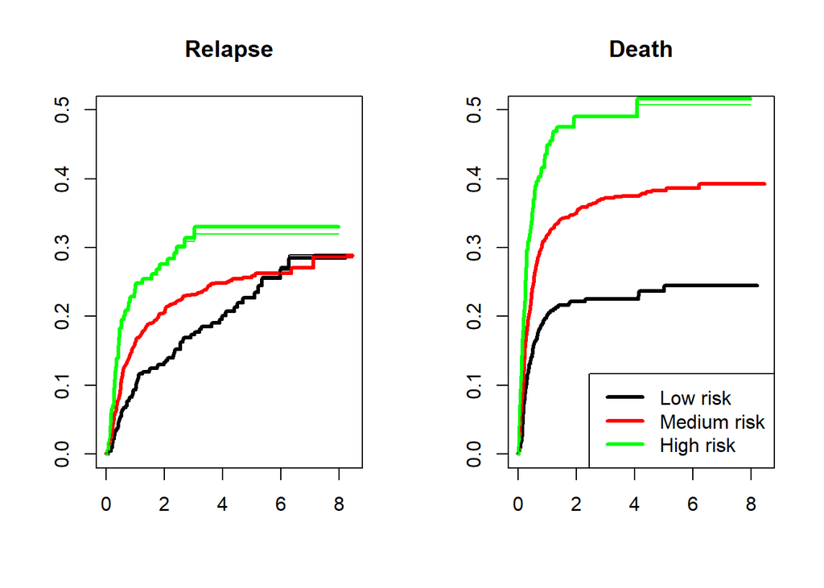

```r
############
cuminc.relapse.crprep <- survfit(Surv(Tstart,Tstop,status=="Relapse")~score,
  data=subset(Webmt.score,failcode=="Relapse"), weights=weight.cens)
cuminc.death.crprep <- survfit(Surv(Tstart,Tstop,status=="Death")~score,
               data=subset(Webmt.score,failcode=="Death"), weights=weight.cens)
############
cuminc.relapse.fg <- survfit(Surv(fgstart,fgstop,fgstatus)~score,
                             data=Webmt.Relapse.score, weight=fgwt)
cuminc.death.fg <- survfit(Surv(fgstart,fgstop,fgstatus)~score,
                           data=Webmt.Death.score, weight=fgwt)
par(mfrow=c(1,2))
plot(cuminc.relapse.fg, lwd=3,
  col=c("black","red","green"), fun="event", ylim=c(0,0.5))
lines(survfit(Surv(fgstart,fgstop,fgstatus)~score, data=Webmt.Relapse,
              weights=fgwt), lwd=1, col=c("black","red","green"), fun="event")
title("Relapse")
plot(cuminc.death.fg, lwd=3,
  col=c("black","red","green"), fun="event", ylim=c(0,0.5))
lines(survfit(Surv(fgstart,fgstop,fgstatus)~score, data=Webmt.Death,
              weights=fgwt), lwd=1, col=c("black","red","green"), fun="event")
title("Death")
legend("bottomright", levels(ebmt1$score), col=c("black","red","green"), lwd=3)
```

It is clear that the EBMT risk score has a profound influence on both relapse and death. Note that the low risk and medium risk curves cross for relapse as end point. This suggests some form of non-proportionality.

It is also seen that the estimates with one overall weight function are almost the same.

- Estimate and plot the time to censoring distribution for each value of `score`. Does the distribution depend on the value of the EBMT risk score? Does this observation correspond to the amount of dependence on the weight function in the estimate of the crude risk?

We change the role of event and censoring. This is a classical survival setting, not a competing risks setting. Therefore, we can use standard code for survival analysis.

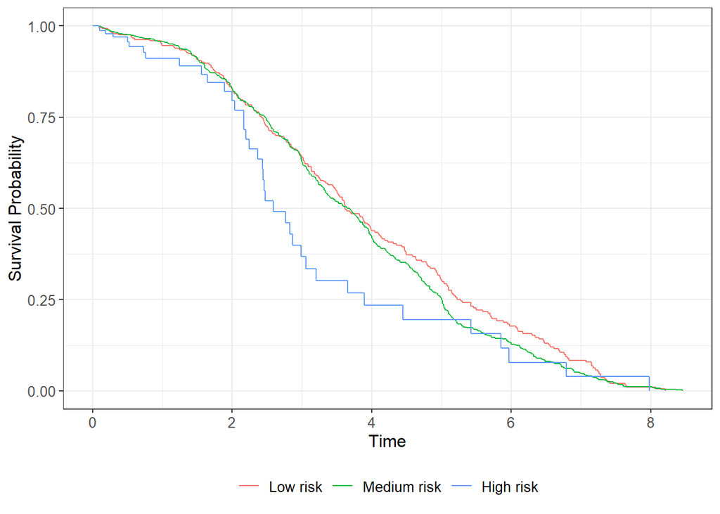

```r
ggsurvfit(survfit2(Surv(time,stat==0)~score, data=ebmt1))
```

The time-to-censoring distribution is almost the same for the low and medium risk groups. For the high risk group, the censoring occurs earlier.

### 10. Log-rank tests

Run and compare the three commands given below. Why is the output from the first and the second different and what do these commands test. Why do the second and the third give the same value of the test statistic.

```r
coxph(Surv(Tstart,Tstop,status=="Relapse")~score, data=
 subset(Webmt.score,failcode=="Relapse"), weights=weight.cens)$score
```

```
[1] 11.50557
```

```r
coxph(Surv(Tstart,Tstop,status=="Relapse")~score,
        data=subset(Webmt.score,failcode=="Relapse"&count==1))$score
```

```
[1] 36.90983
```

```r
survdiff(Surv(time,stat==1)~score,data=ebmt1)
```

```
Call:
survdiff(formula = Surv(time, stat == 1) ~ score, data = ebmt1)

                     N Observed Expected (O-E)^2/E (O-E)^2/V
score=Low risk     406       79    116.4    12.000     16.21
score=Medium risk 1404      328    315.0     0.539      1.75
score=High risk    167       49     24.7    24.023     25.54

 Chisq= 36.9  on 2 degrees of freedom, p= 1e-08
```

The first code performs a log-rank test with respect to the subdistribution hazards. Hence, it tests whether the relapse-specific cumulative incidences are equal for the three EBMT scores. The second and third perform a log-rank test on the cause-specific hazards. Hence, it is a nonparametric test for equality of the cause-specific hazards.

### 11. Impact of EBMT score on subdistribution hazards

- Fit a proportional subdistribution hazards model for the impact of score on both relapse and death as first event. Compare results with those from the proportional cause-specific hazards model. Use the weights that do not depend on score[^1] (using score-specific weights hardly changes results).

```r
fitsdh.rel <- coxph(Surv(Tstart,Tstop,status=="Relapse")~score,
                       data=Webmt, subset=failcode=="Relapse", weights=weight.cens)
fitsdh.death <- coxph(Surv(Tstart,Tstop,status=="Death")~score,
                       data=Webmt, subset=failcode=="Death", weights=weight.cens)
fitsdh.rel
```

```
Call:
coxph(formula = Surv(Tstart, Tstop, status == "Relapse") ~ score,
    data = Webmt, weights = weight.cens, subset = failcode ==
        "Relapse")

                   coef exp(coef) se(coef) robust se     z        p
scoreMedium risk 0.2401    1.2714   0.1253    0.1186 2.024 0.042961
scoreHigh risk   0.5712    1.7704   0.1819    0.1695 3.370 0.000751

Likelihood ratio test=9.64  on 2 df, p=0.008087
n= 94284, number of events= 456
```

```r
fitsdh.death
```

```
Call:
coxph(formula = Surv(Tstart, Tstop, status == "Death") ~ score,
    data = Webmt, weights = weight.cens, subset = failcode ==
        "Death")

                   coef exp(coef) se(coef) robust se     z        p
scoreMedium risk 0.5702    1.7687   0.1132    0.1114 5.121 3.04e-07
scoreHigh risk   0.9832    2.6730   0.1530    0.1460 6.734 1.65e-11

Likelihood ratio test=45.74  on 2 df, p=1.171e-10
n= 33446, number of events= 685
```

## Footnotes

[^1]: Currently the `finegray` function has a bug in the calculation of covariate specific weights. It does not affect the PL-estimate, but it does affect the Fine and Gray model. See this [issue](https://github.com/therneau/survival/issues/329)